# Starbucks Capstone Challenge

### Introduction

This data set contains simulated data that mimics customer behavior on the Starbucks rewards mobile app. Once every few days, Starbucks sends out an offer to users of the mobile app. An offer can be merely an advertisement for a drink or an actual offer such as a discount or BOGO (buy one get one free). Some users might not receive any offer during certain weeks.

Not all users receive the same offer, and that is the challenge to solve with this data set.

Your task is to combine transaction, demographic and offer data to determine which demographic groups respond best to which offer type. This data set is a simplified version of the real Starbucks app because the underlying simulator only has one product whereas Starbucks actually sells dozens of products.

Every offer has a validity period before the offer expires. As an example, a BOGO offer might be valid for only 5 days. You'll see in the data set that informational offers have a validity period even though these ads are merely providing information about a product; for example, if an informational offer has 7 days of validity, you can assume the customer is feeling the influence of the offer for 7 days after receiving the advertisement.

You'll be given transactional data showing user purchases made on the app including the timestamp of purchase and the amount of money spent on a purchase. This transactional data also has a record for each offer that a user receives as well as a record for when a user actually views the offer. There are also records for when a user completes an offer.

Keep in mind as well that someone using the app might make a purchase through the app without having received an offer or seen an offer.

### Example

To give an example, a user could receive a discount offer buy 10 dollars get 2 off on Monday. The offer is valid for 10 days from receipt. If the customer accumulates at least 10 dollars in purchases during the validity period, the customer completes the offer.

However, there are a few things to watch out for in this data set. Customers do not opt into the offers that they receive; in other words, a user can receive an offer, never actually view the offer, and still complete the offer. For example, a user might receive the "buy 10 dollars get 2 dollars off offer", but the user never opens the offer during the 10 day validity period. The customer spends 15 dollars during those ten days. There will be an offer completion record in the data set; however, the customer was not influenced by the offer because the customer never viewed the offer.

### Cleaning

This makes data cleaning especially important and tricky.

You'll also want to take into account that some demographic groups will make purchases even if they don't receive an offer. From a business perspective, if a customer is going to make a 10 dollar purchase without an offer anyway, you wouldn't want to send a buy 10 dollars get 2 dollars off offer. You'll want to try to assess what a certain demographic group will buy when not receiving any offers.

### Final Advice

Because this is a capstone project, you are free to analyze the data any way you see fit. For example, you could build a machine learning model that predicts how much someone will spend based on demographics and offer type. Or you could build a model that predicts whether or not someone will respond to an offer. Or, you don't need to build a machine learning model at all. You could develop a set of heuristics that determine what offer you should send to each customer (i.e., 75 percent of women customers who were 35 years old responded to offer A vs 40 percent from the same demographic to offer B, so send offer A).

# Data Sets

The data is contained in three files:

- portfolio.json - containing offer ids and meta data about each offer (duration, type, etc.)
- profile.json - demographic data for each customer
- transcript.json - records for transactions, offers received, offers viewed, and offers completed

Here is the schema and explanation of each variable in the files:

**portfolio.json**

- id (string) - offer id
- offer_type (string) - type of offer ie BOGO, discount, informational
- difficulty (int) - minimum required spend to complete an offer
- reward (int) - reward given for completing an offer
- duration (int) - time for offer to be open, in days
- channels (list of strings)

**profile.json**

- age (int) - age of the customer
- became_member_on (int) - date when customer created an app account
- gender (str) - gender of the customer (note some entries contain 'O' for other rather than M or F)
- id (str) - customer id
- income (float) - customer's income

**transcript.json**

- event (str) - record description (ie transaction, offer received, offer viewed, etc.)
- person (str) - customer id
- time (int) - time in hours since start of test. The data begins at time t=0
- value - (dict of strings) - either an offer id or transaction amount depending on the record

```python
import pandas as pd
import numpy as np
import math
import json
# % matplotlib inline

# read in the json files
portfolio = pd.read_json('data/portfolio.json', orient='records', lines=True)
profile = pd.read_json('data/profile.json', orient='records', lines=True)
transcript = pd.read_json('data/transcript.json', orient='records', lines=True)
```

## Step 1: Load, Explore and Visualize Data

### Visualize DataFrames

```python
portfolio
```

|  | reward | channels | difficulty | duration | offer_type | id |
| --- | --- | --- | --- | --- | --- | --- |
| 0 | 10 | [email, mobile, social] | 10 | 7 | bogo | ae264e3637204a6fb9bb56bc8210ddfd |
| 1 | 10 | [web, email, mobile, social] | 10 | 5 | bogo | 4d5c57ea9a6940dd891ad53e9dbe8da0 |
| 2 | 0 | [web, email, mobile] | 0 | 4 | informational | 3f207df678b143eea3cee63160fa8bed |
| 3 | 5 | [web, email, mobile] | 5 | 7 | bogo | 9b98b8c7a33c4b65b9aebfe6a799e6d9 |
| 4 | 5 | [web, email] | 20 | 10 | discount | 0b1e1539f2cc45b7b9fa7c272da2e1d7 |
| 5 | 3 | [web, email, mobile, social] | 7 | 7 | discount | 2298d6c36e964ae4a3e7e9706d1fb8c2 |
| 6 | 2 | [web, email, mobile, social] | 10 | 10 | discount | fafdcd668e3743c1bb461111dcafc2a4 |
| 7 | 0 | [email, mobile, social] | 0 | 3 | informational | 5a8bc65990b245e5a138643cd4eb9837 |
| 8 | 5 | [web, email, mobile, social] | 5 | 5 | bogo | f19421c1d4aa40978ebb69ca19b0e20d |
| 9 | 2 | [web, email, mobile] | 10 | 7 | discount | 2906b810c7d4411798c6938adc9daaa5 |

```python
profile.head()
```

|  | gender | age | id | became_member_on | income |
| --- | --- | --- | --- | --- | --- |
| 0 | None | 118 | 68be06ca386d4c31939f3a4f0e3dd783 | 20170212 | NaN |
| 1 | F | 55 | 0610b486422d4921ae7d2bf64640c50b | 20170715 | 112000.0 |
| 2 | None | 118 | 38fe809add3b4fcf9315a9694bb96ff5 | 20180712 | NaN |
| 3 | F | 75 | 78afa995795e4d85b5d9ceeca43f5fef | 20170509 | 100000.0 |
| 4 | None | 118 | a03223e636434f42ac4c3df47e8bac43 | 20170804 | NaN |

```python
transcript.head()
```

|  | person | event | value | time |
| --- | --- | --- | --- | --- |
| 0 | 78afa995795e4d85b5d9ceeca43f5fef | offer received | {'offer id': '9b98b8c7a33c4b65b9aebfe6a799e6d9'} | 0 |
| 1 | a03223e636434f42ac4c3df47e8bac43 | offer received | {'offer id': '0b1e1539f2cc45b7b9fa7c272da2e1d7'} | 0 |
| 2 | e2127556f4f64592b11af22de27a7932 | offer received | {'offer id': '2906b810c7d4411798c6938adc9daaa5'} | 0 |
| 3 | 8ec6ce2a7e7949b1bf142def7d0e0586 | offer received | {'offer id': 'fafdcd668e3743c1bb461111dcafc2a4'} | 0 |
| 4 | 68617ca6246f4fbc85e91a2a49552598 | offer received | {'offer id': '4d5c57ea9a6940dd891ad53e9dbe8da0'} | 0 |

```python
# Extracting offer id from the value column's dictionaries
transcript_value = transcript[transcript['event'] != 'transaction']['value'].apply(pd.Series)
transcript_value = transcript_value.fillna('').drop('reward', axis=1)
transcript_value['offer_id'] = transcript_value['offer_id'] + transcript_value['offer id']
transcript_value = transcript_value.drop('offer id', axis=1)
transcript_value.head()
```

|  | offer_id |
| --- | --- |
| 0 | 9b98b8c7a33c4b65b9aebfe6a799e6d9 |
| 1 | 0b1e1539f2cc45b7b9fa7c272da2e1d7 |
| 2 | 2906b810c7d4411798c6938adc9daaa5 |
| 3 | fafdcd668e3743c1bb461111dcafc2a4 |
| 4 | 4d5c57ea9a6940dd891ad53e9dbe8da0 |

```python
# Assigning value column ONLY the offer id
transcript['value'] = transcript_value
transcript_offers = transcript[transcript['event'] != 'transaction']
transcript_offers.head()
```

|  | person | event | value | time |
| --- | --- | --- | --- | --- |
| 0 | 78afa995795e4d85b5d9ceeca43f5fef | offer received | 9b98b8c7a33c4b65b9aebfe6a799e6d9 | 0 |
| 1 | a03223e636434f42ac4c3df47e8bac43 | offer received | 0b1e1539f2cc45b7b9fa7c272da2e1d7 | 0 |
| 2 | e2127556f4f64592b11af22de27a7932 | offer received | 2906b810c7d4411798c6938adc9daaa5 | 0 |
| 3 | 8ec6ce2a7e7949b1bf142def7d0e0586 | offer received | fafdcd668e3743c1bb461111dcafc2a4 | 0 |
| 4 | 68617ca6246f4fbc85e91a2a49552598 | offer received | 4d5c57ea9a6940dd891ad53e9dbe8da0 | 0 |

## Step 2: Clean and Pre-process Data

### Combine all 3 *.json* files into a single DataFrame and drop useless columns

```python
df = transcript_offers.merge(profile, how='inner', left_on='person', right_on='id').drop(['person', 'id'], axis=1)
df = df.merge(portfolio, how='inner', left_on='value', right_on='id').drop(['value', 'id'], axis=1)
df = df.drop('became_member_on', axis=1)
df.head()
```

|  | event | time | gender | age | income | reward | channels | difficulty | duration | offer_type |
| --- | --- | --- | --- | --- | --- | --- | --- | --- | --- | --- |
| 0 | offer received | 0 | F | 75 | 100000.0 | 5 | [web, email, mobile] | 5 | 7 | bogo |
| 1 | offer viewed | 6 | F | 75 | 100000.0 | 5 | [web, email, mobile] | 5 | 7 | bogo |
| 2 | offer completed | 132 | F | 75 | 100000.0 | 5 | [web, email, mobile] | 5 | 7 | bogo |
| 3 | offer received | 408 | M | 68 | 70000.0 | 5 | [web, email, mobile] | 5 | 7 | bogo |
| 4 | offer viewed | 420 | M | 68 | 70000.0 | 5 | [web, email, mobile] | 5 | 7 | bogo |

### Fill incomplete features

Features: `gender`, `income`

```python
# We can see that gender and income features both have nan values
df.isnull().sum()
```

```
event             0
time              0
gender        18776
age               0
income        18776
reward            0
channels          0
difficulty        0
duration          0
offer_type        0
dtype: int64
```

```python
# Fill income nan values with mean of all incomes
df['income'].fillna(df['income'].mean(), inplace=True)
```

```python
# Fill gender nan values with M or F
fill_list = ['M', 'F']
random_series = pd.Series(np.random.choice(fill_list, size=len(df['gender'])))
df['gender'].fillna(random_series, inplace=True)
```

```python
# Check that there are no more Nan values
df.isnull().sum()
```

```
event         0
time          0
gender        0
age           0
income        0
reward        0
channels      0
difficulty    0
duration      0
offer_type    0
dtype: int64
```

### Drop categorical features

```python
df.drop(['gender', 'channels', 'offer_type'], axis=1, inplace=True)
df.head()
```

|  | event | time | age | income | reward | difficulty | duration |
| --- | --- | --- | --- | --- | --- | --- | --- |
| 0 | offer received | 0 | 75 | 100000.0 | 5 | 5 | 7 |
| 1 | offer viewed | 6 | 75 | 100000.0 | 5 | 5 | 7 |
| 2 | offer completed | 132 | 75 | 100000.0 | 5 | 5 | 7 |
| 3 | offer received | 408 | 68 | 70000.0 | 5 | 5 | 7 |
| 4 | offer viewed | 420 | 68 | 70000.0 | 5 | 5 | 7 |

### Normalize numerical featuers

Features: `reward`, `difficulty`, `duation`, `age`, `income`, `time`

```python
from sklearn.preprocessing import MinMaxScaler

numerical_features = ['time', 'age', 'income', 'difficulty', 'duration', 'reward']

scaler = MinMaxScaler((0, 1))
df_pca = pd.DataFrame(scaler.fit_transform(df[numerical_features].astype(float)))
df_pca.index = df.index
df_pca.columns = numerical_features
df_pca.head()
```

|  | time | age | income | difficulty | duration | reward |
| --- | --- | --- | --- | --- | --- | --- |
| 0 | 0.000000 | 0.57 | 0.777778 | 0.25 | 0.571429 | 0.5 |
| 1 | 0.008403 | 0.57 | 0.777778 | 0.25 | 0.571429 | 0.5 |
| 2 | 0.184874 | 0.57 | 0.777778 | 0.25 | 0.571429 | 0.5 |
| 3 | 0.571429 | 0.50 | 0.444444 | 0.25 | 0.571429 | 0.5 |
| 4 | 0.588235 | 0.50 | 0.444444 | 0.25 | 0.571429 | 0.5 |

```python
# Ensure minimum value is 0 and maximum value is 1
df_pca.describe()
```

|  | time | age | income | difficulty | duration | reward |
| --- | --- | --- | --- | --- | --- | --- |
| count | 167581.000000 | 167581.000000 | 167581.000000 | 167581.000000 | 167581.000000 | 167581.000000 |
| mean | 0.495488 | 0.438626 | 0.404601 | 0.392520 | 0.515820 | 0.441991 |
| std | 0.277733 | 0.256932 | 0.225077 | 0.252447 | 0.305161 | 0.337336 |
| min | 0.000000 | 0.000000 | 0.000000 | 0.000000 | 0.000000 | 0.000000 |
| 25% | 0.235294 | 0.270000 | 0.244444 | 0.250000 | 0.285714 | 0.200000 |
| 50% | 0.571429 | 0.400000 | 0.404601 | 0.500000 | 0.571429 | 0.500000 |
| 75% | 0.714286 | 0.540000 | 0.533333 | 0.500000 | 0.571429 | 0.500000 |
| max | 1.000000 | 1.000000 | 1.000000 | 1.000000 | 1.000000 | 1.000000 |

```python
# Append scaled features to original DataFrame
df[numerical_features] = df_pca
df.head()
```

|  | event | time | age | income | reward | difficulty | duration |
| --- | --- | --- | --- | --- | --- | --- | --- |
| 0 | offer received | 0.000000 | 0.57 | 0.777778 | 0.5 | 0.25 | 0.571429 |
| 1 | offer viewed | 0.008403 | 0.57 | 0.777778 | 0.5 | 0.25 | 0.571429 |
| 2 | offer completed | 0.184874 | 0.57 | 0.777778 | 0.5 | 0.25 | 0.571429 |
| 3 | offer received | 0.571429 | 0.50 | 0.444444 | 0.5 | 0.25 | 0.571429 |
| 4 | offer viewed | 0.588235 | 0.50 | 0.444444 | 0.5 | 0.25 | 0.571429 |

### Map labels to 0 and 1

Label: `event`  
Map `offer received` and `offer viewed` to 0 and `offer completed` to 1

```python
df.event.replace(['offer received', 'offer viewed', 'offer completed'], [0, 0, 1], inplace=True)
df.head()
```

|  | event | time | age | income | reward | difficulty | duration |
| --- | --- | --- | --- | --- | --- | --- | --- |
| 0 | 0 | 0.000000 | 0.57 | 0.777778 | 0.5 | 0.25 | 0.571429 |
| 1 | 0 | 0.008403 | 0.57 | 0.777778 | 0.5 | 0.25 | 0.571429 |
| 2 | 1 | 0.184874 | 0.57 | 0.777778 | 0.5 | 0.25 | 0.571429 |
| 3 | 0 | 0.571429 | 0.50 | 0.444444 | 0.5 | 0.25 | 0.571429 |
| 4 | 0 | 0.588235 | 0.50 | 0.444444 | 0.5 | 0.25 | 0.571429 |

## Step 3: Visualize Data

### Calculate percentage of *offers completed*:

Formula: `# of offers completed / # of offers received`

```python
num_offers_completed = df['event'].sum()
num_offers_received = sum(transcript['event'] == 'offer received')

print('Percentage of offers completed: {0:.2f}%'.format(num_offers_completed*100/num_offers_received))
```

```
Percentage of offers completed: 44.02%
```

### Calculate percentage of *transactions that involved offers*:

Formula: `# of offers completed / (# of transactions - # of offers completed)`

```python
num_transactions = sum(transcript['event'] == 'transaction')
print('Percentage of transactions that involved offers: {0:.2f}%'
      .format(num_offers_completed*100/(num_transactions - num_offers_completed)))
```

```
Percentage of transactions that involved offers: 31.87%
```

## Step 4: Split data into train/test datasets

Note: labels will be the `events` feature

```python
from sklearn.model_selection import train_test_split

# 70% of the data will be training, and 30% of the data will be testing
X_train, X_test, y_train, y_test = train_test_split(df.drop('event', axis=1),
                                                    df['event'],
                                                    test_size=0.3,
                                                    random_state=0,
                                                    shuffle=True)

print("Training set has {} samples.".format(X_train.shape[0]))
print("Testing set has {} samples.".format(X_test.shape[0]))
```

```
Training set has 117306 samples.
Testing set has 50275 samples.
```

## Step 5: Reduce dimensionality using PCA and find vectors of maximal variance

### Define helper functions

```python
from sklearn.decomposition import PCA
import matplotlib.pyplot as plt

def pca_results(full_dataset, pca):
    '''
    Create a DataFrame of the PCA results
    Includes dimension feature weights and explained variance
    Visualizes the PCA results
    '''

    # Dimension indexing
    dimensions = dimensions = ['Dimension {}'.format(i) for i in range(1,len(pca.components_)+1)]

    # PCA components
    components = pd.DataFrame(np.round(pca.components_, 4), columns = full_dataset.keys())
    components.index = dimensions

    # PCA explained variance
    ratios = pca.explained_variance_ratio_.reshape(len(pca.components_), 1)
    variance_ratios = pd.DataFrame(np.round(ratios, 4), columns = ['Explained Variance'])
    variance_ratios.index = dimensions

    # Create a bar plot visualization
    fig, ax = plt.subplots(figsize = (14,8))

    # Plot the feature weights as a function of the components
    components.plot(ax = ax, kind = 'bar');
    ax.set_ylabel("Feature Weights")
    ax.set_xticklabels(dimensions, rotation=0)

    # Display the explained variance ratios
    for i, ev in enumerate(pca.explained_variance_ratio_):
        ax.text(i-0.40, ax.get_ylim()[1] + 0.05, "Explained Variance\n %.4f"%(ev))

    # Return a concatenated DataFrame
    return pd.concat([variance_ratios, components], axis = 1)


def plot_component(pca, comp):
    '''
    Plots an image associated with each component to understand how the weighting
    of the components
    INPUT:
          pca - pca object created from PCA in sklearn
          comp - int - the component you want to see starting at 0
    OUTPUT
          None
    '''
    if comp <= len(pca.components_):
        mat_data = np.asmatrix(pca.components_[comp]).reshape(28,28)  #reshape images
        plt.imshow(mat_data); #plot the data
        plt.xticks([]) #removes numbered labels on x-axis
        plt.yticks([]) #removes numbered labels on y-axis
    else:
        print('That is not the right input, please read the docstring before continuing.')


def scree_plot(pca):
    '''
    Creates a scree plot associated with the principal components

    INPUT: pca - the result of instantian of PCA in scikit learn

    OUTPUT:
            None
    '''
    num_components=len(pca.explained_variance_ratio_)
    ind = np.arange(num_components)
    vals = pca.explained_variance_ratio_

    plt.figure(figsize=(10, 6))
    ax = plt.subplot(111)
    cumvals = np.cumsum(vals)
    ax.bar(ind, vals)
    ax.plot(ind, cumvals)
    for i in range(num_components):
        ax.annotate(r"%s%%" % ((str(vals[i]*100)[:4])), (ind[i]+0.2, vals[i]), va="bottom", ha="center", fontsize=12)

    ax.xaxis.set_tick_params(width=0)
    ax.yaxis.set_tick_params(width=2, length=12)

    ax.set_xlabel("Principal Component")
    ax.set_ylabel("Variance Explained (%)")
    plt.title('Explained Variance Per Principal Component')
```

### Apply PCA, calculate explained variance for each component, and examine component makeup

|  | 0 | 1 | 2 | 3 | 4 | 5 | 6 |
| --- | --- | --- | --- | --- | --- | --- | --- |
| 0 | -0.204490 | -0.172259 | -0.000782 | 0.431856 | 0.334149 | 0.268811 | -0.164446 |
| 1 | -0.203608 | -0.171270 | -0.000605 | 0.423612 | 0.333240 | 0.268989 | -0.164469 |
| 2 | 0.552522 | 0.486117 | 0.134047 | 0.399784 | 0.377238 | 0.189607 | -0.146714 |
| 3 | -0.154326 | -0.109677 | 0.011093 | -0.111654 | 0.052010 | 0.021914 | -0.162543 |
| 4 | -0.152561 | -0.107698 | 0.011446 | -0.128143 | 0.050190 | 0.022269 | -0.162589 |
| ... | ... | ... | ... | ... | ... | ... | ... |
| 167576 | -0.139737 | -0.007683 | -0.146793 | -0.327206 | -0.029887 | 0.262289 | -0.035757 |
| 167577 | 0.597868 | 0.628931 | -0.015848 | -0.177903 | 0.033217 | 0.179177 | -0.017518 |
| 167578 | -0.129865 | 0.004334 | -0.137410 | -0.284534 | -0.392976 | 0.258041 | -0.034258 |
| 167579 | -0.126336 | 0.008290 | -0.136704 | -0.317511 | -0.396615 | 0.258752 | -0.034350 |
| 167580 | 0.622737 | 0.657764 | -0.003465 | -0.275384 | -0.345339 | 0.177949 | -0.016411 |

167581 rows × 7 columns

|  | Explained Variance | event | time | age | income | reward | difficulty | duration |
| --- | --- | --- | --- | --- | --- | --- | --- | --- |
| Dimension 1 | 0.2989 | 0.7376 | 0.1050 | -0.0535 | 0.0407 | 0.3241 | 0.3893 | 0.4287 |
| Dimension 2 | 0.2158 | 0.6366 | 0.1177 | -0.0513 | 0.0248 | -0.5219 | -0.4271 | -0.3505 |
| Dimension 3 | 0.1627 | 0.1309 | 0.0210 | -0.0334 | 0.0074 | 0.7474 | -0.2002 | -0.6186 |
| Dimension 4 | 0.1203 | 0.1493 | -0.9811 | -0.1187 | -0.0264 | -0.0125 | -0.0151 | -0.0058 |
| Dimension 5 | 0.1147 | 0.0631 | -0.1083 | 0.8689 | 0.4783 | 0.0085 | -0.0073 | -0.0189 |
| Dimension 6 | 0.0705 | -0.0831 | 0.0211 | -0.4736 | 0.8764 | -0.0147 | 0.0089 | -0.0014 |
| Dimension 7 | 0.0173 | 0.0182 | -0.0027 | 0.0012 | -0.0107 | -0.2522 | 0.7909 | -0.5571 |

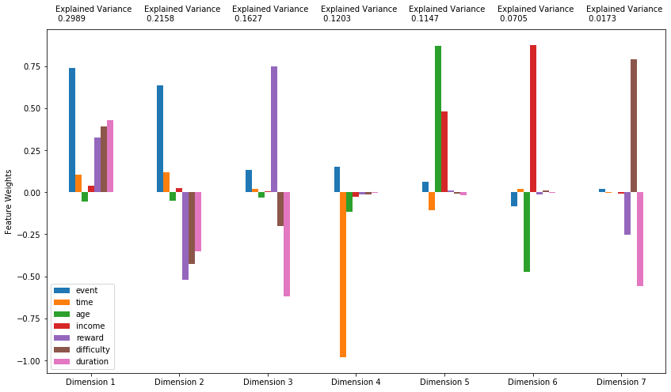

```python
# Apply PCA to data
pca = PCA()
df_pca = pd.DataFrame(pca.fit_transform(df))

# Investigate the variance accounted for by each principal component
pca_output = pca_results(df, pca)

display(df_pca)
display(pca_output)
```

### Observations

We can see that *reward* and *event* are both strongly present in the first 2-3 principal components. This verifies our hypothesis that reward size does dictate whether or not someone will complete an offer.  
Note: The reverse, completing an offer indicates a fairly big reward size, is also plausible.

### Define top *n* components to use in transformed data

```
Cumulative variance for PCA with 5 components: 0.9122532526697498
```

|  | 0 | 1 | 2 | 3 | 4 |
| --- | --- | --- | --- | --- | --- |
| 0 | -0.204490 | -0.172259 | -0.000782 | 0.431856 | 0.334149 |
| 1 | -0.203608 | -0.171270 | -0.000605 | 0.423612 | 0.333240 |
| 2 | 0.552522 | 0.486117 | 0.134047 | 0.399784 | 0.377238 |
| 3 | -0.154326 | -0.109677 | 0.011093 | -0.111654 | 0.052010 |
| 4 | -0.152561 | -0.107698 | 0.011446 | -0.128143 | 0.050190 |
| ... | ... | ... | ... | ... | ... |
| 167576 | -0.139737 | -0.007683 | -0.146793 | -0.327206 | -0.029887 |
| 167577 | 0.597868 | 0.628931 | -0.015848 | -0.177903 | 0.033217 |
| 167578 | -0.129865 | 0.004334 | -0.137410 | -0.284534 | -0.392976 |
| 167579 | -0.126336 | 0.008290 | -0.136704 | -0.317511 | -0.396615 |
| 167580 | 0.622737 | 0.657764 | -0.003465 | -0.275384 | -0.345339 |

167581 rows × 5 columns

|  | Explained Variance | event | time | age | income | reward | difficulty | duration |
| --- | --- | --- | --- | --- | --- | --- | --- | --- |
| Dimension 1 | 0.2989 | 0.7376 | 0.1050 | -0.0535 | 0.0407 | 0.3241 | 0.3893 | 0.4287 |
| Dimension 2 | 0.2158 | 0.6366 | 0.1177 | -0.0513 | 0.0248 | -0.5219 | -0.4271 | -0.3505 |
| Dimension 3 | 0.1627 | 0.1309 | 0.0210 | -0.0334 | 0.0074 | 0.7474 | -0.2002 | -0.6186 |
| Dimension 4 | 0.1203 | 0.1493 | -0.9811 | -0.1187 | -0.0264 | -0.0125 | -0.0151 | -0.0058 |
| Dimension 5 | 0.1147 | 0.0631 | -0.1083 | 0.8689 | 0.4783 | 0.0085 | -0.0073 | -0.0189 |

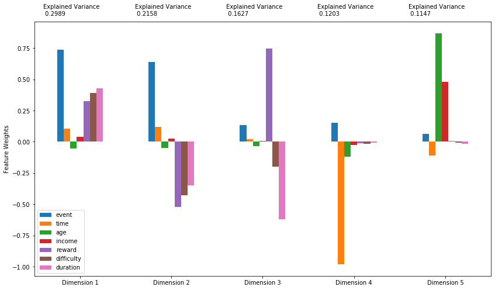

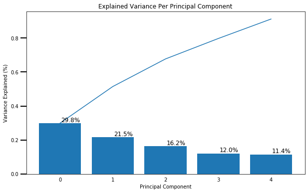

```python
# Re-apply PCA to data while selecting top 5 components to retain
pca_5 = PCA(5)
df_pca_5 = pd.DataFrame(pca_5.fit_transform(df))
pca_5_output = pca_results(df, pca_5)

# Check cumulative variacne for PCA with top 5 components
print('Cumulative variance for PCA with 5 components:', pca_5.explained_variance_ratio_.sum())

display(df_pca_5)
display(pca_5_output)
scree_plot(pca_5)
```

### Interpret Principal Components

```python
# Check principal components
components_df = pd.DataFrame(pca_5.components_)
components_df.columns = df.columns
components_df
```

|  | event | time | age | income | reward | difficulty | duration |
| --- | --- | --- | --- | --- | --- | --- | --- |
| 0 | 0.737605 | 0.104973 | -0.053457 | 0.040687 | 0.324137 | 0.389299 | 0.428705 |
| 1 | 0.636615 | 0.117713 | -0.051346 | 0.024828 | -0.521887 | -0.427105 | -0.350467 |
| 2 | 0.130945 | 0.021005 | -0.033435 | 0.007405 | 0.747356 | -0.200228 | -0.618552 |
| 3 | 0.149304 | -0.981075 | -0.118691 | -0.026387 | -0.012488 | -0.015084 | -0.005814 |
| 4 | 0.063104 | -0.108267 | 0.868905 | 0.478349 | 0.008517 | -0.007337 | -0.018892 |

```python
# Hepled function to map each feature weight to its corresponding feature name, then sort according to weight
def principal_component_feature(index, components_df):
    sorted_components_df = components_df.sort_values(components_df.index[index], axis=1)
    return sorted_components_df.iloc[[index]]
```

```python
# Check first principal component
principal_component_feature(0, components_df)
```

|  | age | income | time | reward | difficulty | duration | event |
| --- | --- | --- | --- | --- | --- | --- | --- |
| 0 | -0.053457 | 0.040687 | 0.104973 | 0.324137 | 0.389299 | 0.428705 | 0.737605 |

```python
# Check second principal component
principal_component_feature(1, components_df)
```

|  | reward | difficulty | duration | age | income | time | event |
| --- | --- | --- | --- | --- | --- | --- | --- |
| 1 | -0.521887 | -0.427105 | -0.350467 | -0.051346 | 0.024828 | 0.117713 | 0.636615 |

```python
# Check third principal component
principal_component_feature(2, components_df)
```

|  | duration | difficulty | age | income | time | event | reward |
| --- | --- | --- | --- | --- | --- | --- | --- |
| 2 | -0.618552 | -0.200228 | -0.033435 | 0.007405 | 0.021005 | 0.130945 | 0.747356 |

### Observations

#### Principal Component 1

- Most negative feature: *age*
- Most positive feature: *event*

#### Principal Component 2

- Most negative feature: *reward*
- Most positive feature: *event*

#### Principal Component 3

- Most negative feature: *duration*
- Most positive feature: *reward*

## Step 6: Test and evaluate several supervised learning algorithms with default parameters and pick the one with the highest accuracy and f-score

### Create a training and predicting pipeline

```python
from sklearn.metrics import fbeta_score, accuracy_score
from time import time

def train_predict(learner, sample_size, X_train, y_train, X_test, y_test):

    results = {}

    # Truncate all training data to hold at max sample_size
    X_train = X_train[:sample_size]
    y_train = y_train[:sample_size]

    # Fit learner to training data
    start = time()
    learner = learner.fit(X_train, y_train)
    end = time()
    results['train_time'] = end-start

    # Get predictions on testing data
    start = time()
    predictions_test = learner.predict(X_test)
    predictions_train = learner.predict(X_train)
    end = time()
    results['prediction_time'] = end-start

    # Compute accuracy on train data
    results['accuracy_train'] = accuracy_score(y_train, predictions_train)

    # Compute accuracy on test data
    results['accuracy_test'] = accuracy_score(y_test, predictions_test)

    # Compute f-score on train data
    results['fscore_train'] = fbeta_score(y_train, predictions_train, beta=0.5)

    # Compute f-score on test data
    results['fscore_test'] = fbeta_score(y_test, predictions_test, beta=0.5)

    print('{} trained on {} samples!'.format(learner.__class__.__name__, sample_size))
    return results
```

### Test several models on 1000 samples

```python
from sklearn.naive_bayes import GaussianNB
from sklearn.tree import DecisionTreeClassifier
from sklearn.svm import SVC
from sklearn.ensemble import AdaBoostClassifier
from sklearn.neighbors import KNeighborsClassifier
from sklearn.linear_model import SGDClassifier

# Initialize models to test
gaussian_model = GaussianNB()
tree_model = DecisionTreeClassifier()
svc_model = SVC()
adaboost_model = AdaBoostClassifier()
knearest_model = KNeighborsClassifier()

# Dictionary to hold results
results = {}
sample_size = 1000

# For all models
for model in [gaussian_model, tree_model, svc_model, adaboost_model, knearest_model]:

    # Get model name
    model_name = model.__class__.__name__
    results[model_name] = train_predict(model, sample_size, X_train, y_train, X_test, y_test)

    print('{0} accuracy on test data: {1:0.3f}'.format(model_name, results[model_name]['accuracy_test']))
    print('{0} f-beta score on test data: {1:0.3f}\n'.format(model_name, results[model_name]['fscore_test']))
```

```
GaussianNB trained on 1000 samples!
GaussianNB accuracy on test data: 0.792
GaussianNB f-beta score on test data: 0.111

DecisionTreeClassifier trained on 1000 samples!
DecisionTreeClassifier accuracy on test data: 0.779
DecisionTreeClassifier f-beta score on test data: 0.432

SVC trained on 1000 samples!
SVC accuracy on test data: 0.798
SVC f-beta score on test data: 0.000

AdaBoostClassifier trained on 1000 samples!
AdaBoostClassifier accuracy on test data: 0.814
AdaBoostClassifier f-beta score on test data: 0.462

KNeighborsClassifier trained on 1000 samples!
KNeighborsClassifier accuracy on test data: 0.767
KNeighborsClassifier f-beta score on test data: 0.256
```

#### Observations

The F-score for the AdaBoost Classifier on the test set was the highest at *0.462* and accuracy at *0.814*.  
We'll tune this model's hyperparameters to hopefully improve it.

## Step 7: Tune Model hyperparameters with most promising algorithm

```python
from sklearn.model_selection import GridSearchCV
from sklearn.metrics import make_scorer

# Initialize model of choice
model = AdaBoostClassifier(random_state=0)

# Create parameter list to tune
parameters = {
    'n_estimators': [25, 50, 75],
    'learning_rate': [1, 0.1, 0.001]
}

# Make f-beta scoring object
scorer = make_scorer(fbeta_score, beta=0.5)

# Perform grid search on classifier using scorer as the scoring method (using all CPUs)
grid_search_obj = GridSearchCV(model, param_grid=parameters, scoring=scorer, n_jobs=-1)

# Find optimal parameter by fitting object to training data
grid_search_fit = grid_search_obj.fit(X_train, y_train)

# Note the best estimator
best_model = grid_search_fit.best_estimator_

# Make predictions using unoptimized and optimized model
predictions = model.fit(X_train, y_train).predict(X_test)
best_predictions = best_model.predict(X_test)
```

## Step 8: Evaluate model using accuracy and f-score

```python
print('Unoptimized {} Model~'.format(model.__class__.__name__))
print('Accuracy on testing data: {:0.4f}'.format(accuracy_score(y_test, predictions)))
print('F-score on testing data: {:0.4f}'.format(fbeta_score(y_test, predictions, beta=0.5)))

print('\nOptimized {} Model~'.format(model.__class__.__name__))
print('Final accuracy score on the testing data: {:0.4f}'.format(accuracy_score(y_test, best_predictions)))
print('Final F-score on the testing data: {:0.4f}'.format(fbeta_score(y_test, best_predictions, beta=0.5)))
```

```
Unoptimized AdaBoostClassifier Model~
Accuracy on testing data: 0.8170
F-score on testing data: 0.4638

Optimized AdaBoostClassifier Model~
Final accuracy score on the testing data: 0.8271
Final F-score on the testing data: 0.5405
```

## Step 9: Compare model performance against a naive predictor that always predicts a customer to respond to an offer

In other words, the naive model always outputs 1

Accuracy:  
True Positives / Number of all Predictions

Precision:  
True Positives / (True Positives + False Positives)

Recall:  
True Positives / (True Positives + False Negatives)

F-beta Score:  
(1 + beta^2) *(precision* recall) / ((beta^2 * precision) + recall)

```python
'''
Details for the Naive Case:

True Positives = np.sum(df['event'])
False Positives = df['event'].count() - True Positives
True Negatives = 0  (No predicted negatives)
False Negatives = 0  (No predicted negatives)
'''

accuracy = np.sum(df['event']) / df['event'].count()

precision = accuracy

recall = 1  # np.sum(df['event'] / (np.sum(df['event']) + 0)

fscore = (1 + 0.5**2) * (precision * recall) / ((0.5**2 * precision) + recall)

print("Naive Predictor: [Accuracy: {:.4f}, F-Beta Score: {:0.4f}]".format(accuracy, fscore))
```

```
Naive Predictor: [Accuracy: 0.2004, F-Beta Score: 0.2385]
```

## Step 10: Concluding Thoughts

The optimized AdaBoost Classifier was only 1% better than the unoptimized model in terms of accuracy, and 17% better in terms of F-Beta Score. Not negligible, but not ground-breaking either.

In terms of comparison with the naive model, it was far better by ~400% in accuracy, and ~225% in terms of F-Beta Score - a significant improvement.